# HW 3: Unsupervised Learning Practice_Pengyun Li

```python
import pandas as pd
import numpy as np
import seaborn as sns
%matplotlib inline
```

## Qn1.1 Use K Means Cluster Analysis to identify cluster(s) of observations that have high and low values of the wine quality. (Assume all variables are continuous.) Describe variables that cluster with higher values of wine quality. Describe variables that cluster with lower values of wine quality.

```python
#Data Cleaning
red = pd.read_csv("https://archive.ics.uci.edu/ml/machine-learning-databases/wine-quality/winequality-red.csv", sep=';')
red.head()
```

|  | fixed acidity | volatile acidity | citric acid | residual sugar | chlorides | free sulfur dioxide | total sulfur dioxide | density | pH | sulphates | alcohol | quality |
| --- | --- | --- | --- | --- | --- | --- | --- | --- | --- | --- | --- | --- |
| 0 | 7.4 | 0.70 | 0.00 | 1.9 | 0.076 | 11.0 | 34.0 | 0.9978 | 3.51 | 0.56 | 9.4 | 5 |
| 1 | 7.8 | 0.88 | 0.00 | 2.6 | 0.098 | 25.0 | 67.0 | 0.9968 | 3.20 | 0.68 | 9.8 | 5 |
| 2 | 7.8 | 0.76 | 0.04 | 2.3 | 0.092 | 15.0 | 54.0 | 0.9970 | 3.26 | 0.65 | 9.8 | 5 |
| 3 | 11.2 | 0.28 | 0.56 | 1.9 | 0.075 | 17.0 | 60.0 | 0.9980 | 3.16 | 0.58 | 9.8 | 6 |
| 4 | 7.4 | 0.70 | 0.00 | 1.9 | 0.076 | 11.0 | 34.0 | 0.9978 | 3.51 | 0.56 | 9.4 | 5 |

```python
#Exploration of Data

quality_level = set(red["quality"])
SO2_level = set(red["free sulfur dioxide"])
print(quality_level)
print(SO2_level)
```

```
{3, 4, 5, 6, 7, 8}
{1.0, 2.0, 3.0, 4.0, 5.0, 6.0, 7.0, 8.0, 9.0, 10.0, 11.0, 12.0, 13.0, 14.0, 15.0, 16.0, 17.0, 18.0, 19.0, 20.0, 21.0, 22.0, 23.0, 24.0, 25.0, 26.0, 27.0, 28.0, 29.0, 30.0, 31.0, 32.0, 33.0, 34.0, 35.0, 36.0, 37.0, 38.0, 39.0, 40.0, 41.0, 42.0, 40.5, 43.0, 45.0, 46.0, 47.0, 48.0, 50.0, 51.0, 52.0, 53…
```

```python
#Standardizing the data (Since we found that there are only 6 levels of quality)
from sklearn import preprocessing
from sklearn.preprocessing import StandardScaler

scaler = preprocessing.StandardScaler().fit(red)
scaled_red = pd.DataFrame(scaler.transform(red), columns = red.columns)
scaled_red.head()
```

|  | fixed acidity | volatile acidity | citric acid | residual sugar | chlorides | free sulfur dioxide | total sulfur dioxide | density | pH | sulphates | alcohol | quality |
| --- | --- | --- | --- | --- | --- | --- | --- | --- | --- | --- | --- | --- |
| 0 | -0.528360 | 0.961877 | -1.391472 | -0.453218 | -0.243707 | -0.466193 | -0.379133 | 0.558274 | 1.288643 | -0.579207 | -0.960246 | -0.787823 |
| 1 | -0.298547 | 1.967442 | -1.391472 | 0.043416 | 0.223875 | 0.872638 | 0.624363 | 0.028261 | -0.719933 | 0.128950 | -0.584777 | -0.787823 |
| 2 | -0.298547 | 1.297065 | -1.186070 | -0.169427 | 0.096353 | -0.083669 | 0.229047 | 0.134264 | -0.331177 | -0.048089 | -0.584777 | -0.787823 |
| 3 | 1.654856 | -1.384443 | 1.484154 | -0.453218 | -0.264960 | 0.107592 | 0.411500 | 0.664277 | -0.979104 | -0.461180 | -0.584777 | 0.450848 |
| 4 | -0.528360 | 0.961877 | -1.391472 | -0.453218 | -0.243707 | -0.466193 | -0.379133 | 0.558274 | 1.288643 | -0.579207 | -0.960246 | -0.787823 |

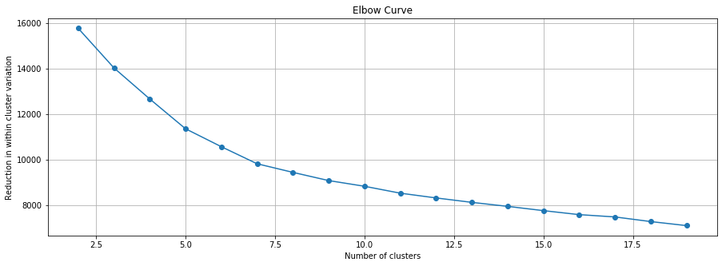

```python
#Now let's plot the Elbow Curve to look for proper k.

from sklearn.cluster import KMeans
from matplotlib import pyplot as plt

within_cluster_variance = [] # initiate empty list with no data

for k in range(2, 20):
    kmeans = KMeans(n_clusters=k)
    kmeans.fit(scaled_red)
    within_cluster_variance.append(kmeans.inertia_)

fig = plt.figure(figsize=(15, 5))
plt.plot(range(2, 20), within_cluster_variance, marker='o')
plt.grid(True)
plt.xlabel('Number of clusters')
plt.ylabel('Reduction in within cluster variation')
plt.title('Elbow Curve');
```

We cannot see a very clear elbow from the curve above, so I will test for k = 5,6,7 as they appear to be possible elbow points.

```python
# k = 5
k5 = KMeans(n_clusters=5, n_init=20).fit(scaled_red)
scaled_red['cluster'] = k5.labels_
pd.Series(k5.labels_).value_counts()
```

```
0    535
1    352
4    340
2    337
3     35
dtype: int64
```

```python
display(scaled_red.groupby('cluster').mean())
```

| cluster | fixed acidity | volatile acidity | citric acid | residual sugar | chlorides | free sulfur dioxide | total sulfur dioxide | density | pH | sulphates | alcohol | quality |
| --- | --- | --- | --- | --- | --- | --- | --- | --- | --- | --- | --- | --- |
| 0 | -0.444059 | 0.678846 | -0.767876 | -0.058895 | -0.055403 | -0.393531 | -0.355885 | 0.011905 | 0.370160 | -0.419926 | -0.472429 | -0.505359 |
| 1 | 1.359267 | -0.707321 | 1.147312 | 0.125147 | -0.010701 | -0.550956 | -0.542322 | 0.771605 | -0.854673 | 0.359806 | 0.220739 | 0.461405 |
| 2 | -0.064644 | 0.045247 | 0.085044 | -0.017847 | -0.032305 | 0.966850 | 1.221534 | 0.258180 | -0.134683 | -0.188880 | -0.601954 | -0.449669 |
| 3 | 0.161077 | 0.046493 | 1.085087 | 0.803571 | 5.050899 | 0.517438 | 0.689525 | 0.617485 | -1.519661 | 3.216177 | -0.949518 | -0.363135 |
| 4 | -0.661009 | -0.385532 | -0.175524 | -0.101922 | -0.389670 | 0.178049 | -0.160278 | -1.137037 | 0.592311 | 0.144398 | 1.209238 | 0.800591 |

When using k = 5, choosing a threshold = 0.5 and -0.5, we are going to use cluster 4 (quality = 0.800591) as high quality, and cluster 0 (quality = -0.505359) as low quality. Then: Variables with a strong positive relationship with high quality wine are pH and alcohol. Variables with a strong negative relationship with high quality wine are fixed acidity and density. Variables with a strong positive relationship with low quality wine are volatile acidity. Variables with a strong negative relationship with low quality wine are citric acid.

```python
# k = 6
k6 = KMeans(n_clusters=6, n_init=20).fit(scaled_red)
scaled_red['cluster'] = k6.labels_

pd.Series(k6.labels_).value_counts()
```

```
3    517
0    352
5    331
2    325
1     45
4     29
dtype: int64
```

```python
display(scaled_red.groupby('cluster').mean())
```

| cluster | fixed acidity | volatile acidity | citric acid | residual sugar | chlorides | free sulfur dioxide | total sulfur dioxide | density | pH | sulphates | alcohol | quality |
| --- | --- | --- | --- | --- | --- | --- | --- | --- | --- | --- | --- | --- |
| 0 | 1.356818 | -0.707321 | 1.148333 | 0.112046 | -0.007984 | -0.551771 | -0.543531 | 0.766199 | -0.853568 | 0.358800 | 0.225272 | 0.464924 |
| 1 | -0.202792 | -0.021964 | 0.387536 | 4.237219 | 0.198371 | 1.652560 | 1.806258 | 1.031753 | -0.179993 | 0.094854 | -0.332379 | -0.237302 |
| 2 | -0.049290 | 0.050593 | 0.074939 | -0.100226 | -0.031693 | 0.960619 | 1.197455 | 0.249317 | -0.146168 | -0.210420 | -0.617607 | -0.437183 |
| 3 | -0.449570 | 0.688334 | -0.788377 | -0.210390 | -0.058672 | -0.453152 | -0.412247 | -0.034787 | 0.383424 | -0.426823 | -0.463978 | -0.507504 |
| 4 | 0.081831 | 0.017955 | 1.144178 | -0.399396 | 5.604731 | -0.070479 | 0.474416 | 0.185803 | -1.687357 | 3.720608 | -0.882563 | -0.360695 |
| 5 | -0.671905 | -0.371198 | -0.216307 | -0.233195 | -0.386768 | 0.132872 | -0.240960 | -1.161820 | 0.624664 | 0.152841 | 1.214062 | 0.791389 |

When using k = 6, choosing a threshold = 0.5 and -0.5, we are going to use cluster 5 (quality = 0.791389) as high quality, and cluster 3 (quality = -0.507504) as low quality. Then: Variables with a strong positive relationship with high quality wine are pH and alcohol. Variables with a strong negative relationship with high quality wine are fixed acidity and density. Variables with a strong positive relationship with low quality wine are volatile acidity. Variables with a strong negative relationship with low quality wine are citric acid.

This yields a same result as when k = 5.

```python
# k = 7
k7 = KMeans(n_clusters=7, n_init=20).fit(scaled_red)
scaled_red['cluster'] = k7.labels_

pd.Series(k7.labels_).value_counts()
```

```
0    515
1    351
2    325
6    175
4    158
3     46
5     29
dtype: int64
```

```python
display(scaled_red.groupby('cluster').mean())
```

| cluster | fixed acidity | volatile acidity | citric acid | residual sugar | chlorides | free sulfur dioxide | total sulfur dioxide | density | pH | sulphates | alcohol | quality |
| --- | --- | --- | --- | --- | --- | --- | --- | --- | --- | --- | --- | --- |
| 0 | -0.445694 | 0.680980 | -0.786434 | -0.208621 | -0.056922 | -0.457558 | -0.414324 | -0.028651 | 0.377015 | -0.423939 | -0.468613 | -0.506416 |
| 1 | 1.359407 | -0.705392 | 1.148839 | 0.099305 | -0.009613 | -0.549835 | -0.541834 | 0.764965 | -0.853580 | 0.360799 | 0.224638 | 0.464964 |
| 2 | -0.049290 | 0.050593 | 0.074939 | -0.100226 | -0.031693 | 0.960619 | 1.197455 | 0.249317 | -0.146168 | -0.210420 | -0.617607 | -0.437183 |
| 3 | -0.188637 | -0.051583 | 0.400212 | 4.244759 | 0.206318 | 1.589869 | 1.742223 | 1.035402 | -0.194548 | 0.085332 | -0.315419 | -0.222342 |
| 4 | -1.103981 | 0.359386 | -0.967018 | -0.248907 | -0.427323 | 0.316406 | -0.133936 | -1.362824 | 1.248455 | -0.063776 | 1.327124 | 0.560604 |
| 5 | 0.081831 | 0.017955 | 1.144178 | -0.399396 | 5.604731 | -0.070479 | 0.474416 | 0.185803 | -1.687357 | 3.720608 | -0.882563 | -0.360695 |
| 6 | -0.290668 | -0.997061 | 0.449222 | -0.223956 | -0.351554 | -0.026564 | -0.333432 | -0.985519 | 0.077573 | 0.333304 | 1.106443 | 0.981707 |

When using k = 7, choosing a threshold = 0.5 and -0.5, we are going to use cluster 6 (quality = 0.981707) as high quality, and cluster 0 (quality = -0.506416) as low quality. Then: Variables with a strong positive relationship with high quality wine are alcohol. Variables with a strong negative relationship with high quality wine are volatile acidity and density. Variables with a strong positive relationship with low quality wine are volatile acidity. Variables with a strong negative relationship with low quality wine are citric acid.

## Qn 1.2 If you want to make a good bottle of wine, then what characteristics are most important according to this analysis?

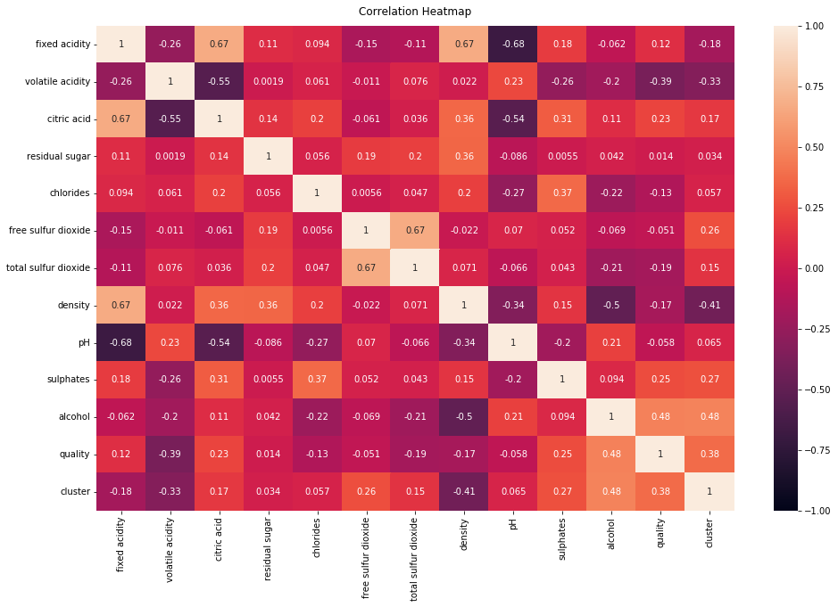

```python
plt.figure(figsize=(16, 10))

heatmap = sns.heatmap(scaled_red.corr(), vmin=-1, vmax=1, annot=True)

heatmap.set_title('Correlation Heatmap', fontdict={'fontsize':12}, pad=12)
```

As seen from the correlation heatmap above, the variable that is most positively correlated with the red wine quality is alcohol (corr = 0.48), and the variable that is most negatively correlated with the red wine quality is volatile acidicity (corr = -0.39). This finding coincide with the results we derived when k = 7. Thus, having a cluster of 7 may be a proper answer. Therefore, according to my analysis in part 1.1, taking k = 7, we should focus on variables that have strong positive relationship with high quality wine as well as the ones with strong negative relationship with low quality wine. Thus, the most important features for making high quality wine are alcohol and citric acid.

## Qn 2.1 Use Hierarchical Cluster Analysis to identify cluster(s) of observations that have high and low values of the wine quality. (Assume all variables are continuous.) Use complete linkage and the same number of groups that you found to be the most meaningful in question 1. Describe variables that cluster with higher values of wine quality. Describe variables that cluster with lower values of wine quality.

```python
# Notice that we have found k = 7 to be the most proper cluster size in question 1.
from scipy.cluster import hierarchy
from scipy.cluster.hierarchy import fcluster
from scipy.cluster.hierarchy import linkage

row_clusters = linkage(scaled_red.values, metric='euclidean', method='complete')

scaled_red['cluster'] = fcluster(row_clusters, 7, criterion='maxclust')
scaled_red.groupby('cluster').mean()
```

| cluster | fixed acidity | volatile acidity | citric acid | residual sugar | chlorides | free sulfur dioxide | total sulfur dioxide | density | pH | sulphates | alcohol | quality |
| --- | --- | --- | --- | --- | --- | --- | --- | --- | --- | --- | --- | --- |
| 1 | 0.074897 | -0.350945 | 3.127368 | 0.043416 | 11.116408 | 0.394484 | 0.320274 | 0.770280 | -2.663717 | 5.735193 | -0.960246 | -1.407158 |
| 2 | 0.054378 | 0.000205 | 0.966981 | -0.425346 | 4.984709 | -0.032439 | 0.555943 | 0.132749 | -1.643230 | 3.646551 | -0.876436 | -0.301202 |
| 3 | -0.624115 | -1.291336 | 1.364336 | 5.293553 | -0.675866 | 3.167777 | 5.956069 | -1.185471 | -1.259873 | -0.815259 | 1.136122 | 1.276629 |
| 4 | 0.284822 | -0.598039 | 0.630946 | 6.832574 | 0.639140 | 0.982981 | 0.505067 | 1.903286 | -0.500635 | 0.115332 | -0.599218 | 0.069719 |
| 5 | -0.679624 | -0.359283 | -0.218996 | -0.237940 | -0.388993 | 0.149127 | -0.220008 | -1.170061 | 0.625822 | 0.137406 | 1.204351 | 0.776231 |
| 6 | 1.257681 | -0.649772 | 1.071774 | 0.081249 | 0.019926 | -0.438555 | -0.451694 | 0.740187 | -0.774286 | 0.426129 | 0.170402 | 0.387489 |
| 7 | -0.323557 | 0.467673 | -0.473187 | -0.054341 | -0.055096 | 0.120139 | 0.253536 | 0.092035 | 0.187087 | -0.393319 | -0.531128 | -0.489763 |

Choosing a threshold = 1 and -1, we are going to use cluster 3 (quality = 1.276629) as high quality, and cluster 1 (quality = -1.407158) as low quality. Then: Variables with a strong positive relationship with high quality wine are citric acid, residual sugar, free sulfur dioxide, total sulfur dioxide, and alcohol. Variables with a strong negative relationship with high quality wine are volatile acidity, pH and density. Variables with a strong positive relationship with low quality wine are citric acid, chlorides, and sulphates. Variables with a strong negative relationship with low quality wine are pH.

## Qn 2.2 If you want to make a good bottle of wine, then what characteristics are most important according to this analysis? Have your conclusions changed using Hierarchical clustering rather than k means clustering? Present any figures that assist you in your analysis.

According to my analysis in part 2.1, we should focus on variables that have strong positive relationship with high quality wine as well as the ones with strong negative relationship with low quality wine. Thus, the most important features for making high quality wine are high quality wine are citric acid, residual sugar, free sulfur dioxide, total sulfur dioxide, alcohol, and pH. This is quite different from when we are using k means clustering.

Let's use Agglomerative methods to show the dendrogram.

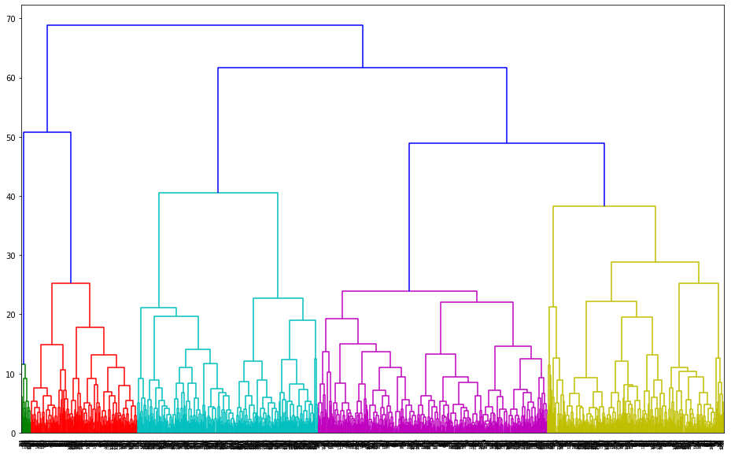

```python
import scipy.cluster.hierarchy as sch
from sklearn.cluster import AgglomerativeClustering

plt.figure(figsize=(16, 10))
dendrogram = sch.dendrogram(sch.linkage(scaled_red[list(scaled_red.columns)[:-1]], method='ward'))
hc = AgglomerativeClustering(n_clusters=7, affinity = 'euclidean', linkage = 'complete')
```

If we use agglomerative clustering we can see that 5 clusters is the recommanded number of clusters instead.

## Qn 3 Use Principal Components Analysis to reduce the dimensions of your data. How much of the variation in your data is explained by the first two principal components. How might you use the first two components to do supervised learning on some other variable tied to wine (e.g. - wine price)?

```python
scaled_red2 = scaled_red.iloc[:,:-1]
scaled_red2.head()
```

|  | fixed acidity | volatile acidity | citric acid | residual sugar | chlorides | free sulfur dioxide | total sulfur dioxide | density | pH | sulphates | alcohol | quality |
| --- | --- | --- | --- | --- | --- | --- | --- | --- | --- | --- | --- | --- |
| 0 | -0.528360 | 0.961877 | -1.391472 | -0.453218 | -0.243707 | -0.466193 | -0.379133 | 0.558274 | 1.288643 | -0.579207 | -0.960246 | -0.787823 |
| 1 | -0.298547 | 1.967442 | -1.391472 | 0.043416 | 0.223875 | 0.872638 | 0.624363 | 0.028261 | -0.719933 | 0.128950 | -0.584777 | -0.787823 |
| 2 | -0.298547 | 1.297065 | -1.186070 | -0.169427 | 0.096353 | -0.083669 | 0.229047 | 0.134264 | -0.331177 | -0.048089 | -0.584777 | -0.787823 |
| 3 | 1.654856 | -1.384443 | 1.484154 | -0.453218 | -0.264960 | 0.107592 | 0.411500 | 0.664277 | -0.979104 | -0.461180 | -0.584777 | 0.450848 |
| 4 | -0.528360 | 0.961877 | -1.391472 | -0.453218 | -0.243707 | -0.466193 | -0.379133 | 0.558274 | 1.288643 | -0.579207 | -0.960246 | -0.787823 |

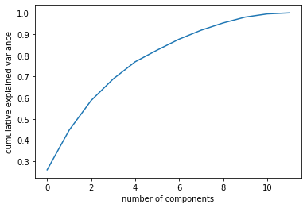

```python
from sklearn.decomposition import PCA

pca = PCA().fit(scaled_red2)
plt.plot(np.cumsum(pca.explained_variance_ratio_))
plt.xlabel('number of components')
plt.ylabel('cumulative explained variance')
```

```python
pca = PCA(n_components=2).fit(scaled_red2)
PC1, PC2 = pca.explained_variance_ratio_
print(PC1 + PC2)
```

```
0.44692081170691733
```

As seen from the result, 44.692% of the variation in my data is explained by the first two principal components.

```python
scaled_red2.columns
```

```
Index(['fixed acidity', 'volatile acidity', 'citric acid', 'residual sugar',
       'chlorides', 'free sulfur dioxide', 'total sulfur dioxide', 'density',
       'pH', 'sulphates', 'alcohol', 'quality'],
      dtype='object')
```

```python
pca.components_
```

```
array([[ 0.48788336, -0.26512898,  0.47333547,  0.13915442,  0.19742679,
        -0.04588071,  0.00406675,  0.37030119, -0.43272085,  0.25453535,
        -0.07317678,  0.11248878],
       [-0.00417321,  0.33896786, -0.1373581 ,  0.16773634,  0.18978819,
         0.25948314,  0.36397137,  0.33078079, -0.06544015, -0.10933362,
        -0.50270865, -0.47316621]])
```

We can see from the results above that for the first two components, variables such as 'fixed acidity', and 'citric acid' are very different, where both of them are higher in PC1 compared to in PC2. Therefore, we can use logistic regression to build a classification model on the first two principal components to tell the differences between red wines with high and low levels of citric acid and fixed acidity respectively.